# MPDW

Cahyani Dyah Rofiana

2023-10-16

## Library

```r
library(ggplot2)
library(tsibble)
library(tseries)
library(MASS)
library(dplyr)
library(TTR)
library(forecast)
library(lmtest)
library(orcutt)
library(HoRM)
library(dLagM)
library(dynlm)
library(MLmetrics)
library(car)
library(TSA)
library(aTSA)
```

# Import Data

```r
library(rio)
data <- import("https://raw.githubusercontent.com/CahyaniDyahRofiana/PraktikumUTSMPDW/main/Data/data.csv")
str(data)
```

```
## 'data.frame':    139 obs. of  2 variables:
##  $ No                : int  1 2 3 4 5 6 7 8 9 10 ...
##  $ CabaiMerahKeriting: int  56550 53200 48800 40450 58600 63200 53800 58750 55300 49500 ...
```

```r
data
```

```
##      No CabaiMerahKeriting
## 1     1              56550
## 2     2              53200
## 3     3              48800
## 4     4              40450
## 5     5              58600
## 6     6              63200
## 7     7              53800
## 8     8              58750
## 9     9              55300
## 10   10              49500
## 11   11              54400
## 12   12              54650
## 13   13              54200
## 14   14              54000
```

[output cut: 125 more lines]

# Cek Stasioner

## Plot *Time Series*

### Data Penuh

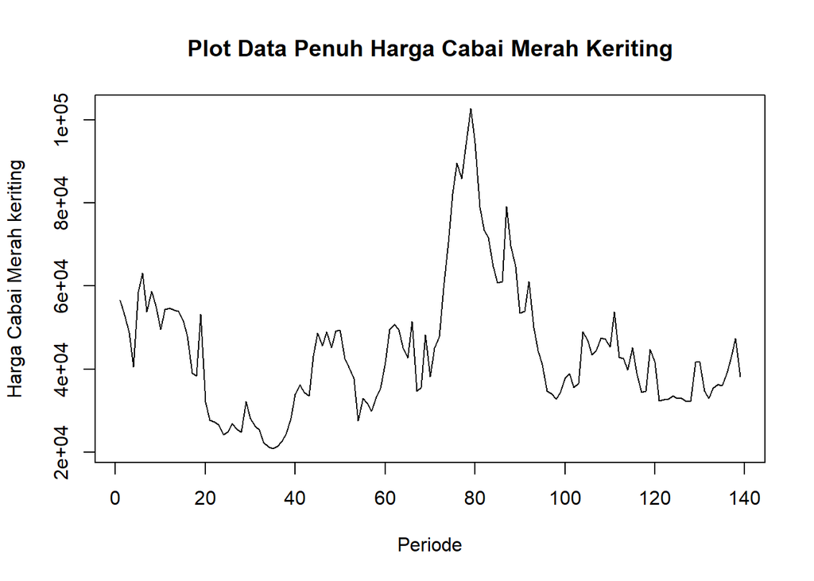

```r
data.ts <- ts(data$CabaiMerahKeriting)
plot.ts(data.ts, lty=1, xlab="Periode", ylab="Harga Cabai Merah keriting", main="Plot Data Penuh Harga Cabai Merah Keriting")
```

### Data Latih

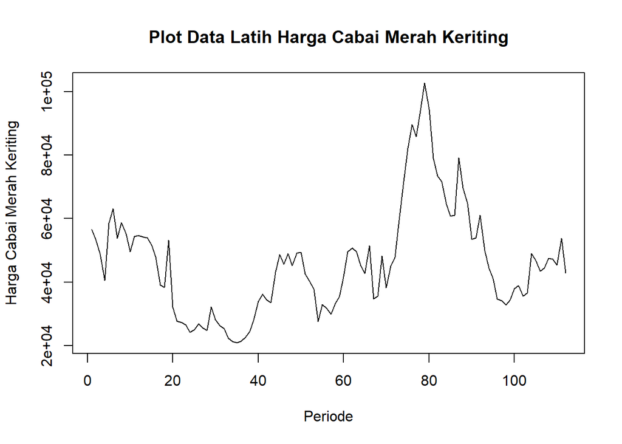

```r
train<-data$CabaiMerahKeriting[1:112]
train.ts<-ts(train)
plot.ts(train.ts, lty=1, xlab="Periode", ylab="Harga Cabai Merah Keriting", main="Plot Data Latih Harga Cabai Merah Keriting")
```

Berdasarkan plot data deret waktu pada data latih, terlihat bahwa data tidak stasioner dalam rataan, ditandai dengan data cenderung tidak menyebar di sekitar nilai tengahnya

### Data Uji

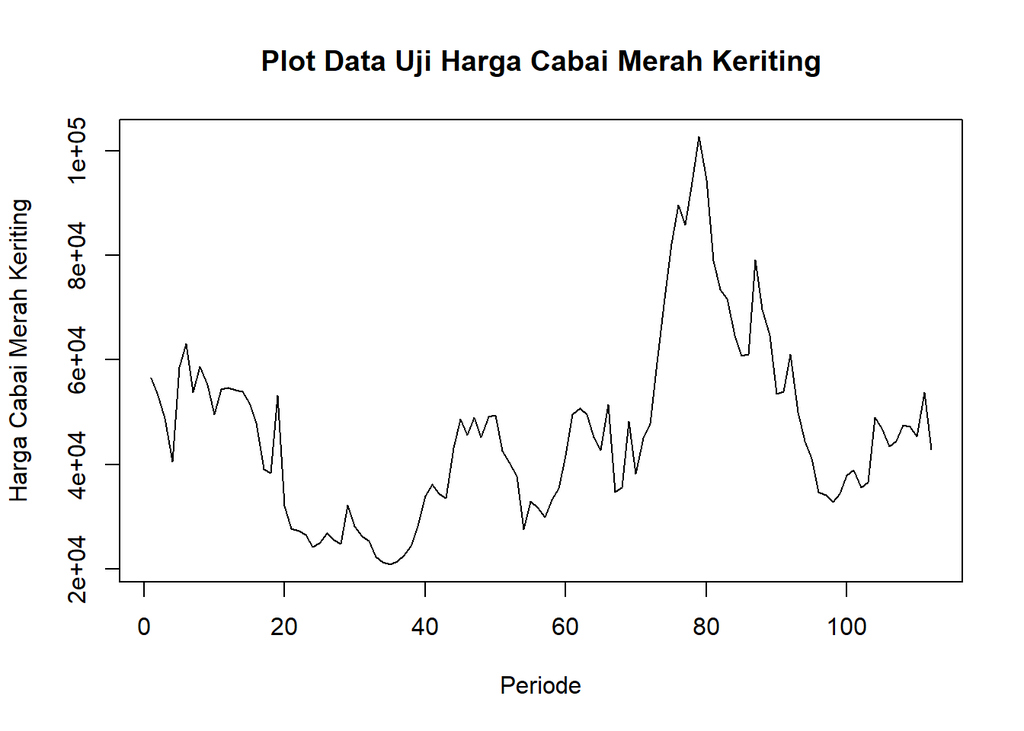

```r
test<-data$CabaiMerahKeriting[-c(113:139)]
test.ts<-ts(test)
plot.ts(test.ts, lty=1, xlab="Periode", ylab="Harga Cabai Merah Keriting", main="Plot Data Uji Harga Cabai Merah Keriting")
```

## Plot ACF

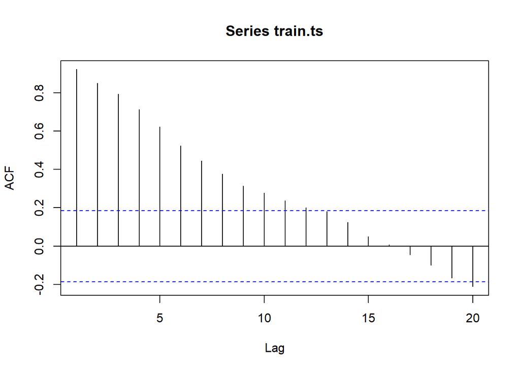

```r
acf(train.ts)
```

Berdasarkan plot ACF, terlihat bahwa plot ACF pada data tersebut *tails off slowly* atau menurun secara perlahan.

## Uji ADF

```r
tseries::adf.test(train.ts)
```

```
##
##  Augmented Dickey-Fuller Test
##
## data:  train.ts
## Dickey-Fuller = -2.6003, Lag order = 4, p-value = 0.3275
## alternative hypothesis: stationary
```

$H_0$ : Data tidak stasioner dalam rataan

$H_1$ : Data stasioner dalam rataan

Berdasarkan uji ADF tersebut, didapat *p-value* sebesar 0.3275 yang lebih besar dari taraf nyata 5% sehingga tak tolak $H_0$ dan menandakan bahwa data tidak stasioner dalam rataan. Hal ini sesuai dengan hasil eksplorasi menggunakan plot time series dan plot ACF, sehingga ketidakstasioneran model kedepannya harus ditangani

## Plot Box-Cox

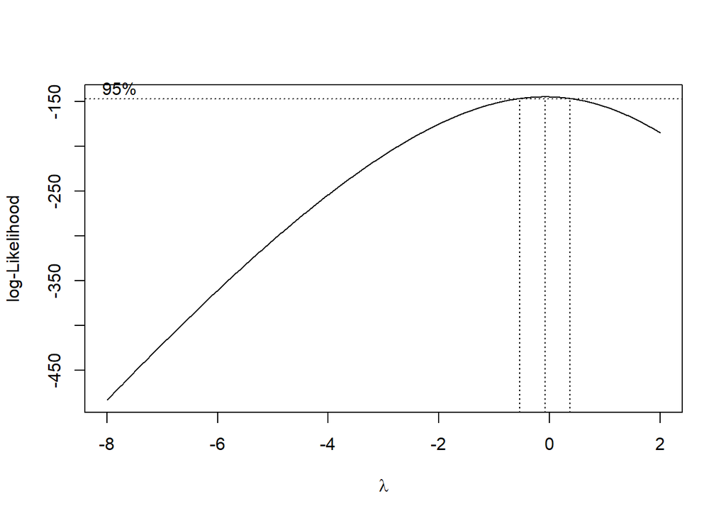

```r
index <- seq(1:112)
bc = boxcox(train.ts~index, lambda = seq(-8,2,by=0.01))
```

```r
#Nilai Rounded Lambda
lambda <- bc$x[which.max(bc$y)]
lambda
```

```
## [1] -0.08
```

```r
#SK
bc$x[bc$y > max(bc$y) - 1/2 * qchisq(.95,1)]
```

```
##  [1] -0.54 -0.53 -0.52 -0.51 -0.50 -0.49 -0.48 -0.47 -0.46 -0.45 -0.44 -0.43
## [13] -0.42 -0.41 -0.40 -0.39 -0.38 -0.37 -0.36 -0.35 -0.34 -0.33 -0.32 -0.31
## [25] -0.30 -0.29 -0.28 -0.27 -0.26 -0.25 -0.24 -0.23 -0.22 -0.21 -0.20 -0.19
## [37] -0.18 -0.17 -0.16 -0.15 -0.14 -0.13 -0.12 -0.11 -0.10 -0.09 -0.08 -0.07
## [49] -0.06 -0.05 -0.04 -0.03 -0.02 -0.01  0.00  0.01  0.02  0.03  0.04  0.05
## [61]  0.06  0.07  0.08  0.09  0.10  0.11  0.12  0.13  0.14  0.15  0.16  0.17
## [73]  0.18  0.19  0.20  0.21  0.22  0.23  0.24  0.25  0.26  0.27  0.28  0.29
## [85]  0.30  0.31  0.32  0.33  0.34  0.35  0.36  0.37
```

Gambar di atas menunjukkan nilai *rounded value* ($\lambda$) optimum sebesar **=-0.08** dan pada selang kepercayaan 95% nilai memiliki batas bawah **-0.54* dan batas atas *0.37**. Selang tersebut tidak memuat nilai 1 sehingga dapat dikatakan bahwa data tidak stasioner dalam ragam.

Dengan demikian, data tidak stasioner dalam rataan tetapi tidak stasioner dalam ragam.

#Penanganan Ketidakstasioneran Data

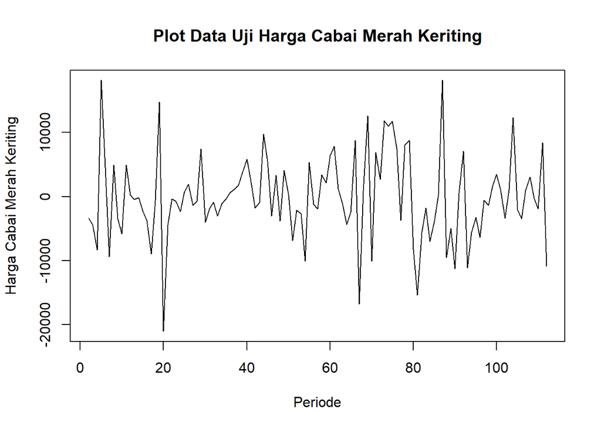

```r
train.diff<-diff(train.ts,differences = 1)
plot.ts(train.diff, lty=1, xlab="Periode", ylab="Harga Cabai Merah Keriting", main="Plot Data Uji Harga Cabai Merah Keriting")
```

Berdasarkan plot data deret waktu, terlihat bahwa data sudah stasioner dalam rataan ditandai dengan data bergerak pada nilai tengah tertentu (tidak terdapat trend ataupun musiman pada data)

# Identifikasi Model

##Plot ADF

```r
tseries::adf.test(train.diff)
```

```
##
##  Augmented Dickey-Fuller Test
##
## data:  train.diff
## Dickey-Fuller = -3.6926, Lag order = 4, p-value = 0.02812
## alternative hypothesis: stationary
```

$H_0$ : Data tidak stasioner dalam rataan

$H_1$ : Data stasioner dalam rataan

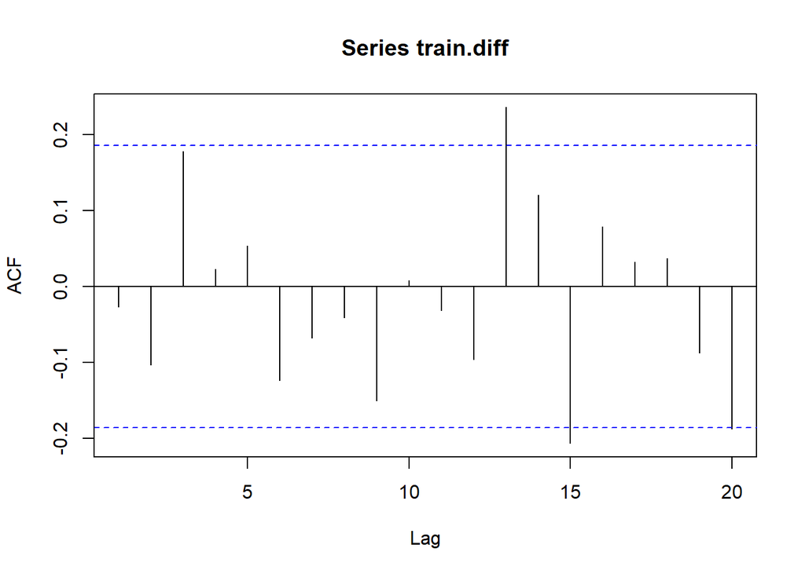

```r
acf(train.diff)
```

Berdasarkan plot tersebut, terlihat bahwa plot ACF *cuts off*,sehingga jika plot PACF dianggap tails of, maka model tentatifnya adalah ARIMA(0,1,13).

## Plot PACF

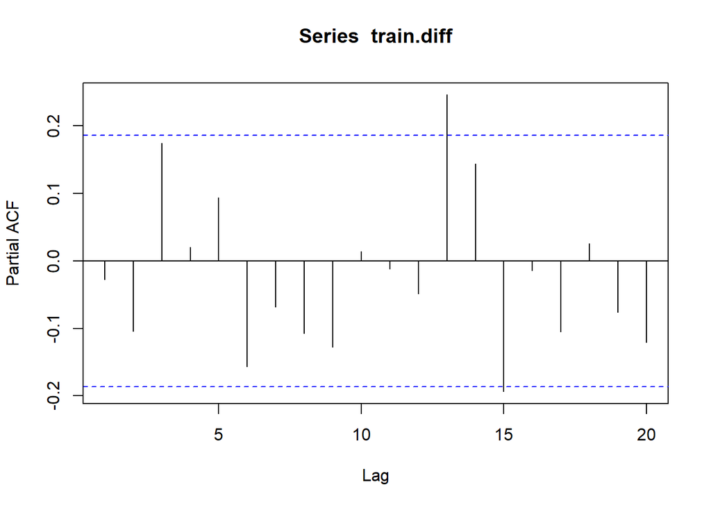

```r
pacf(train.diff)
```

Berdasarkan plot tersebut, terlihat bahwa plot PACF cenderung cuts off pada lag ke 13, sehingga jika plot ACF dianggap tails of, maka model tentatifnya adalah ARIMA(13,1,0).

## Plot EACF

```r
eacf(train.diff)
```

```
## AR/MA
##   0 1 2 3 4 5 6 7 8 9 10 11 12 13
## 0 o o o o o o o o o o o  o  x  o
## 1 x o x o o o o o o o o  o  x  o
## 2 x x o o o o o o o o o  o  o  o
## 3 o x x o o o o o o o o  o  o  o
## 4 o o x o o o o o o o o  o  o  o
## 5 x x x o o o o o o o o  o  o  o
## 6 x x o x o x o o o o o  o  o  o
## 7 x o o x o o o o o o o  o  o  o
```

Identifikasi model menggunakan plot EACF dilakukan dengan melihat ujung segitiga pada pola segitiga nol. Dalam hal ini model tentatif yang terbentuk adalah ARIMA(0,1,2) dan ARIMA (1,1,3), ARIMA(2,1,2), dan ARIMA(3,1,3)

# Pendugaan Parameter Model Tentatif

## ARIMA(0,1,2)

```r
model1=Arima(train.diff, order=c(0,1,2),method="ML")
model1
```

```
## Series: train.diff
## ARIMA(0,1,2)
##
## Coefficients:
##           ma1     ma2
##       -1.0229  0.0229
## s.e.   0.1099  0.1058
##
## sigma^2 = 46306484:  log likelihood = -1128.25
## AIC=2262.49   AICc=2262.72   BIC=2270.59
```

```r
summary(model1) #AIC=2262.49
```

```
## Series: train.diff
## ARIMA(0,1,2)
##
## Coefficients:
##           ma1     ma2
##       -1.0229  0.0229
## s.e.   0.1099  0.1058
##
## sigma^2 = 46306484:  log likelihood = -1128.25
## AIC=2262.49   AICc=2262.72   BIC=2270.59
##
## Training set error measures:
##                    ME     RMSE      MAE      MPE     MAPE      MASE
## Training set 316.7188 6712.299 4899.399 87.28061 98.95259 0.7162864
##                      ACF1
## Training set -0.005054529
```

```r
lmtest::coeftest(model1)
```

```
##
## z test of coefficients:
##
##      Estimate Std. Error z value Pr(>|z|)
## ma1 -1.022922   0.109870 -9.3103   <2e-16 ***
## ma2  0.022924   0.105809  0.2167   0.8285
## ---
## Signif. codes:  0 '***' 0.001 '**' 0.01 '*' 0.05 '.' 0.1 ' ' 1
```

## ARIMA(1,1,3)

```r
model2=Arima(train.diff, order=c(1,1,3),method="ML")
summary(model2) #AIC=2262.41
```

```
## Series: train.diff
## ARIMA(1,1,3)
##
## Coefficients:
##           ar1      ma1      ma2     ma3
##       -0.5778  -0.3917  -0.7423  0.1341
## s.e.   0.2044   0.2055   0.1564  0.0943
##
## sigma^2 = 45381381:  log likelihood = -1126.21
## AIC=2262.41   AICc=2262.99   BIC=2275.92
##
## Training set error measures:
##                    ME     RMSE      MAE      MPE     MAPE      MASE        ACF1
## Training set 337.2013 6583.098 4795.876 92.48824 118.5657 0.7011515 -0.01662171
```

```r
lmtest::coeftest(model2) #ar2 signifikan
```

```
##
## z test of coefficients:
##
##      Estimate Std. Error z value  Pr(>|z|)
## ar1 -0.577776   0.204404 -2.8266  0.004704 **
## ma1 -0.391741   0.205535 -1.9060  0.056656 .
## ma2 -0.742306   0.156385 -4.7467 2.068e-06 ***
## ma3  0.134061   0.094293  1.4218  0.155098
## ---
## Signif. codes:  0 '***' 0.001 '**' 0.01 '*' 0.05 '.' 0.1 ' ' 1
```

## ARIMA(2,1,2)

```r
model3=Arima(train.diff, order=c(2,1,2),method="ML")
summary(model3) #AIC=2261.9
```

```
## Series: train.diff
## ARIMA(2,1,2)
##
## Coefficients:
##           ar1      ar2      ma1      ma2
##       -0.7276  -0.1561  -0.2600  -0.7400
## s.e.   0.1736   0.1000   0.1552   0.1537
##
## sigma^2 = 45147744:  log likelihood = -1125.95
## AIC=2261.9   AICc=2262.47   BIC=2275.4
##
## Training set error measures:
##                    ME    RMSE      MAE      MPE     MAPE      MASE        ACF1
## Training set 350.1155 6566.13 4793.842 94.37371 124.1821 0.7008541 0.003241645
```

```r
lmtest::coeftest(model3)
```

```
##
## z test of coefficients:
##
##     Estimate Std. Error z value  Pr(>|z|)
## ar1 -0.72761    0.17358 -4.1919 2.766e-05 ***
## ar2 -0.15607    0.10000 -1.5607   0.11860
## ma1 -0.25998    0.15524 -1.6747   0.09398 .
## ma2 -0.74001    0.15375 -4.8131 1.486e-06 ***
## ---
## Signif. codes:  0 '***' 0.001 '**' 0.01 '*' 0.05 '.' 0.1 ' ' 1
```

## ARIMA(3,1,3)

```r
model4=Arima(train.diff, order=c(3,1,3),method="ML")
summary(model4) #AIC=2264.51
```

```
## Series: train.diff
## ARIMA(3,1,3)
##
## Coefficients:
##           ar1     ar2     ar3      ma1      ma2     ma3
##       -0.1556  0.2111  0.1871  -0.8228  -0.4920  0.3148
## s.e.   0.3627  0.2803  0.1060   0.3623   0.3323  0.2757
##
## sigma^2 = 45588504:  log likelihood = -1125.25
## AIC=2264.51   AICc=2265.61   BIC=2283.41
##
## Training set error measures:
##                    ME     RMSE      MAE      MPE    MAPE      MASE        ACF1
## Training set 337.4888 6535.561 4768.729 97.57422 133.201 0.6971825 -0.01238027
```

```r
lmtest::coeftest(model4)
```

```
##
## z test of coefficients:
##
##     Estimate Std. Error z value Pr(>|z|)
## ar1 -0.15565    0.36269 -0.4291  0.66782
## ar2  0.21111    0.28032  0.7531  0.45138
## ar3  0.18707    0.10600  1.7649  0.07759 .
## ma1 -0.82278    0.36225 -2.2713  0.02313 *
## ma2 -0.49202    0.33230 -1.4806  0.13871
## ma3  0.31482    0.27566  1.1421  0.25343
## ---
## Signif. codes:  0 '***' 0.001 '**' 0.01 '*' 0.05 '.' 0.1 ' ' 1
```

# Diagnostik Model

## Eksplorasi

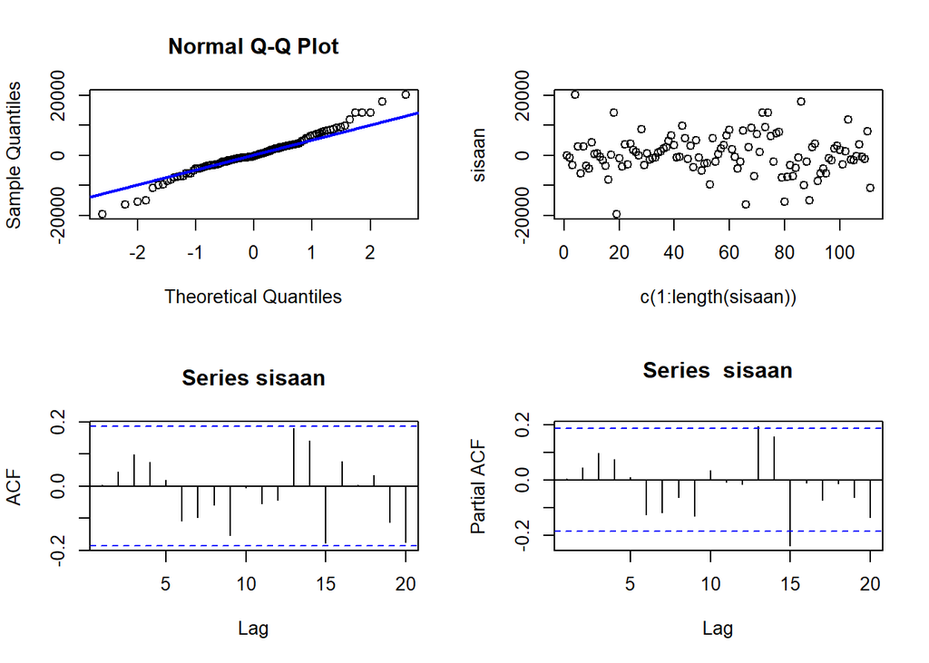

```r
#Eksplorasi
sisaan<- model3$residuals
par(mfrow=c(2,2))
qqnorm(sisaan)
qqline(sisaan, col = "blue", lwd = 2)
plot(c(1:length(sisaan)),sisaan)
acf(sisaan)
pacf(sisaan)
```

```r
par(mfrow = c(1,1))
```

Berdasarkan plot kuantil-kuantil normal, secara eksplorasi ditunjukkan sisaan cenderung menyebar normal mengikuti garis $45^{\circ}$ tetapi beberapa pengamatan di kanan dan kiri tidak mengikuti garis. Kemudian dapat dilihat juga lebar pita sisaan yang cenderung tidak sama menandakan bahwa sisaan memiliki ragam yang heterogen. Kondisi ini akan diuji lebih lanjut dengan uji formal.

## Uji Formal

```r
#1) Sisaan Menyebar Normal
ks.test(sisaan,"pnorm")
```

```
##
##  Asymptotic one-sample Kolmogorov-Smirnov test
##
## data:  sisaan
## D = 0.52212, p-value < 2.2e-16
## alternative hypothesis: two-sided
```

```r
#tak tolak H0 > sisaan menyebar normal
```

Selain dengan eksplorasi, asumsi tersebut dapat diuji menggunakan uji formal. Pada tahapan ini uji formal yang digunakan untuk normalitas adalah uji Kolmogorov-Smirnov (KS). Hipotesis pada uji KS adalah sebagai berikut.

$H_0$ : Sisaan menyebar normal

$H_1$ : Sisaan tidak menyebar normal

Berdasarkan uji KS tersebut, didapat *p-value* sebesar <2.2e-16 yang lebih kecil dari taraf nyata 5% sehingga tolak $H_0$ dan menandakan bahwa sisaan tidak menyebar normal.

```r
#2) Sisaan saling bebas/tidak ada autokorelasi
Box.test(sisaan, type = "Ljung")
```

```
##
##  Box-Ljung test
##
## data:  sisaan
## X-squared = 0.0011982, df = 1, p-value = 0.9724
```

```r
#tak tolak H0 > sisaan saling bebas
```

Selanjutnya akan dilakukan uji formal untuk kebebasan sisaan menggunakan uji Ljung-Box. Hipotesis yang digunakan adalah sebagai berikut.

$H_0$ : Sisaan saling bebas

$H_1$ : Sisaan tidak tidak saling bebas

Berdasarkan uji Ljung-Box tersebut, didapat *p-value* sebesar 0.9724 yang lebih besar dari taraf nyata 5% sehingga tak tolak $H_0$ dan menandakan bahwa sisaan saling bebas.

```r
#3) Sisaan homogen
Box.test((sisaan)^2, type = "Ljung")
```

```
##
##  Box-Ljung test
##
## data:  (sisaan)^2
## X-squared = 0.86587, df = 1, p-value = 0.3521
```

```r
#tak tolak H0 > sisaan homogen
```

Hipotesis yang digunakan untuk uji kehomogenan ragam adalah sebagai berikut.

$H_0$ : Ragam sisaan homogen

$H_1$ : Ragam sisaan tidak homogen

Berdasarkan uji Ljung-Box terhadap sisaan kuadrat tersebut, didapat *p-value* sebesar 0.3521 yang lebih besar dari taraf nyata 5% sehingga terima $H_0$ dan menandakan bahwa ragam sisaan homogen.

```r
#4) Nilai tengah sisaan sama dengan nol
t.test(sisaan, mu = 0, conf.level = 0.95)
```

```
##
##  One Sample t-test
##
## data:  sisaan
## t = 0.56004, df = 110, p-value = 0.5766
## alternative hypothesis: true mean is not equal to 0
## 95 percent confidence interval:
##  -888.8153 1589.0464
## sample estimates:
## mean of x
##  350.1155
```

```r
#tak tolak h0 > nilai tengah sisaan sama dengan 0
```

Terakhir, dengan uji-t, akan dicek apakah nilai tengah sisaan sama dengan nol. Hipotesis yang diujikan sebagai berikut.

$H_0$ : nilai tengah sisaan sama dengan 0

$H_1$ : nilai tengah sisaan tidak sama dengan 0

Berdasarkan uji-ttersebut, didapat *p-value* sebesar 0.5766 yang lebih besar dari taraf nyata 5% sehingga tak tolak $H_0$ dan menandakan bahwa nilai tengah sisaan sama dengan nol.

# Forecasting

```r
ramalan<- forecast::forecast(model3, h =27)
ramalan
```

```
##     Point Forecast      Lo 80     Hi 80     Lo 95    Hi 95
## 113   -1591.442846 -10241.226  7058.340 -14820.14 11637.26
## 114    2615.814579  -6035.593 11267.222 -10615.37 15847.00
## 115   -1890.456317 -10646.160  6865.248 -15281.15 11500.24
## 116     731.725374  -8091.064  9554.514 -12761.57 14225.02
## 117    -472.899906  -9306.651  8360.851 -13982.96 13037.16
## 118      -5.651327  -8843.870  8832.567 -13522.54 13511.24
## 119    -157.617652  -8995.545  8680.309 -13674.06 13358.83
## 120    -119.970004  -8958.110  8718.170 -13636.74 13396.80
## 121    -123.645033  -8961.751  8714.461 -13640.36 13393.07
## 122    -126.846829  -8964.950  8711.256 -13643.56 13389.87
## 123    -123.943586  -8962.054  8714.167 -13640.67 13392.78
## 124    -125.556309  -8963.662  8712.549 -13642.27 13391.16
## 125    -124.835989  -8962.944  8713.272 -13641.56 13391.88
## 126    -125.108400  -8963.216  8712.999 -13641.83 13391.61
## 127    -125.022613  -8963.130  8713.085 -13641.74 13391.70
## 128    -125.042517  -8963.150  8713.065 -13641.76 13391.68
## 129    -125.041424  -8963.149  8713.066 -13641.76 13391.68
## 130    -125.039113  -8963.147  8713.068 -13641.76 13391.68
## 131    -125.040965  -8963.148  8713.067 -13641.76 13391.68
## 132    -125.039978  -8963.147  8713.068 -13641.76 13391.68
## 133    -125.040407  -8963.148  8713.067 -13641.76 13391.68
## 134    -125.040249  -8963.148  8713.067 -13641.76 13391.68
## 135    -125.040297  -8963.148  8713.067 -13641.76 13391.68
## 136    -125.040287  -8963.148  8713.067 -13641.76 13391.68
## 137    -125.040287  -8963.148  8713.067 -13641.76 13391.68
## 138    -125.040288  -8963.148  8713.067 -13641.76 13391.68
## 139    -125.040287  -8963.148  8713.067 -13641.76 13391.68
```

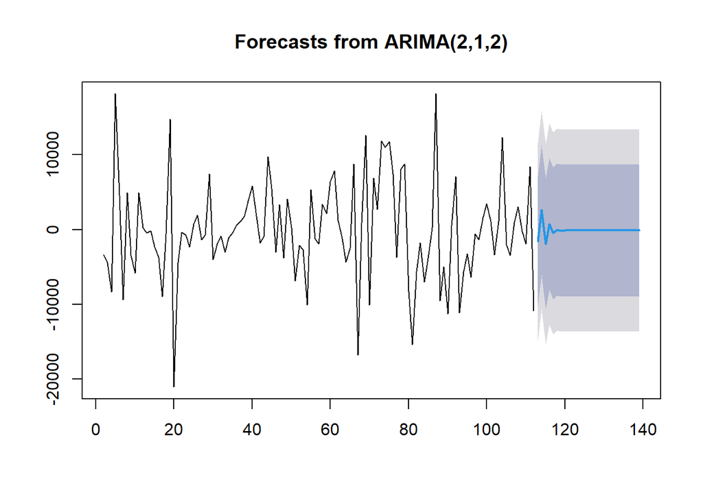

```r
data.ramalan <- ramalan$mean
plot(ramalan)
```

Berdasarkan hasil plot ramalan di atas, dapat dilihat bahwa ramalan ARIMA(2,1,2) cenderung stabil hingga akhir periode. Selanjutnya, dapat dicari nilai akurasi antara hasil ramalan dengan data uji.

# Akurasi

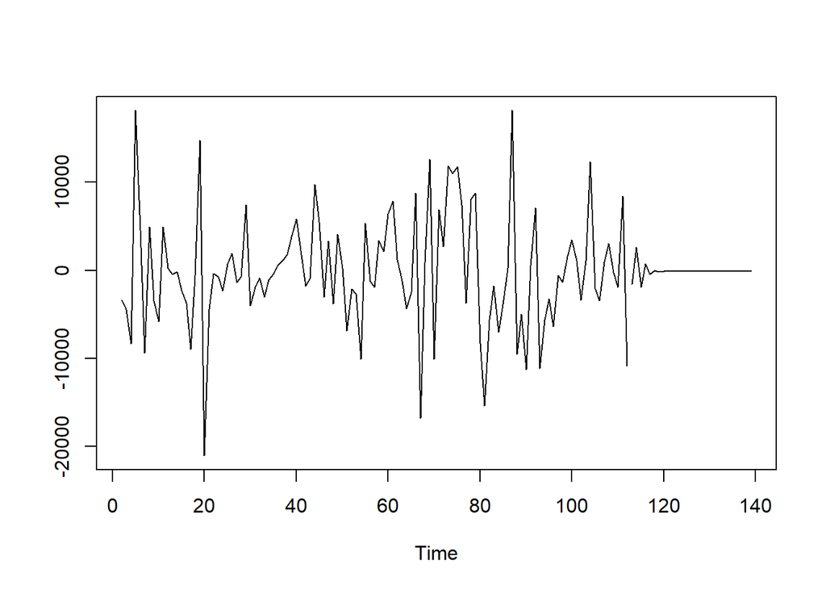

```r
pt_1 <- train.diff[112] #nilai akhir data latih
hasil <- data.ramalan
ts.plot(train.diff,hasil)
```

```r
perbandingan<-matrix(data=c(head(test.ts, n=27), hasil[-1]),
                     nrow = 27, ncol = 2)
colnames(perbandingan)<-c("Aktual","Hasil Forecast")
perbandingan
```

```
##       Aktual Hasil Forecast
##  [1,]  56550    2615.814579
##  [2,]  53200   -1890.456317
##  [3,]  48800     731.725374
##  [4,]  40450    -472.899906
##  [5,]  58600      -5.651327
##  [6,]  63200    -157.617652
##  [7,]  53800    -119.970004
##  [8,]  58750    -123.645033
##  [9,]  55300    -126.846829
## [10,]  49500    -123.943586
## [11,]  54400    -125.556309
## [12,]  54650    -124.835989
## [13,]  54200    -125.108400
## [14,]  54000    -125.022613
## [15,]  51750    -125.042517
## [16,]  48000    -125.041424
## [17,]  39000    -125.039113
## [18,]  38400    -125.040965
## [19,]  53150    -125.039978
## [20,]  32100    -125.040407
## [21,]  27650    -125.040249
## [22,]  27300    -125.040297
## [23,]  26550    -125.040287
## [24,]  24200    -125.040287
## [25,]  24950    -125.040288
## [26,]  26850    -125.040287
## [27,]  25500   56550.000000
```

```r
accuracy(ts(hasil[-1]), head(test.ts, n=27))
```

```
##                ME     RMSE      MAE     MPE    MAPE      ACF1 Theil's U
## Test set 45268.25 46913.19 45268.25 100.205 100.205 0.7689855  6.054743
```

Diperoleh nilai MAPE yang cukup besar sehingga diperlukan evaluasi model lebih lanjut